# MKTG 6620 Final Project

Meag Tessmann

11/22/2020

# Problem Description

Mr. Pixels, the Brand Manager, and Ms. Sence, the Sales Manager, are both currently focusing on improving performance in our orange juice category. We primarily sell two brands in this category, Citrus Hill and Minute Maid. Since Minute Maid offers higher margins than Citrus Hill, we will focus our analysis on improving Minute Maid sales.

The data we’ll be using details purchase data for which brand the customer bought, not whether they purchased orange juice. For this reason, we’ll assume that we are aware of factors going into or likelihood of purchasing any orange juice. In other words, we’re assuming the customer(s) in question have made up their mind to purchase orange juice, and are now considering which brand to purchase.

The brand team’s goal is to increase the likelihood that a customer will purchase our higher margin brand, Minute Maid. To answer this, we will examine which factors positively influence Minute Maid sales and to what extent each of them do by looking at correlations between variables and purchasing Minute Maid.

Building on this analysis, we will also deliver a model for the sales team to predict whether a specific customer will purchase Minute Maid. The model will attempt to predict whether or not a specific customer will purchase Minute Maid in the future based on the factors at that time, as described below.

# Analysis

## Data Description & Cleaning

- which product the customer purchased
- the week of purchase
- the store from which they purchased
- the list price for the product
- the discount offered for the product
- the difference in list price between Minute Maid and Citrus Hill
- the difference in sale price between Minute Maid and Citrus Hill
- whether there was a special for the product, like a free gift or loyalty points
- the probability of brand loyalty towards Citrus Hill brand

The original data set includes 18 variables; a number of these are repeated or derivatives of one another. For example, store is included three times. In each of these cases, I check for discrepancies and reduced variables as needed.

## Store Variables

There are three store variables which contain redundent information. First, I’ll convert the store variables into categorical variables and check the number of categories I have is the same across all variables. Next, I’ll see if any purchases have more than one store associated with it. It looks like they all have consistent store ids, so I reduce these variables down into a single store id variable.

```r
purchases <- purchases %>%
  mutate(
    Store = factor(STORE),
    StoreID = factor(StoreID),
  )
# check if counts are expected, and if any unexpected levels occur
skim(purchases)
```

Data summary

| Name | purchases |
| --- | --- |
| Number of rows | 1070 |
| Number of columns | 19 |
| _______________________ |  |
| Column type frequency: |  |
| factor | 4 |
| numeric | 15 |
| ________________________ |  |
| Group variables | None |

**Variable type: factor**

| skim_variable | n_missing | complete_rate | ordered | n_unique | top_counts |
| --- | --- | --- | --- | --- | --- |
| Purchase | 0 | 1 | FALSE | 2 | CH: 653, MM: 417 |
| StoreID | 0 | 1 | FALSE | 5 | 7: 356, 2: 222, 3: 196, 1: 157 |
| Store7 | 0 | 1 | FALSE | 2 | No: 714, Yes: 356 |
| Store | 0 | 1 | FALSE | 5 | 0: 356, 2: 222, 3: 196, 1: 157 |

**Variable type: numeric**

| skim_variable | n_missing | complete_rate | mean | sd | p0 | p25 | p50 | p75 | p100 | hist |
| --- | --- | --- | --- | --- | --- | --- | --- | --- | --- | --- |
| WeekofPurchase | 0 | 1 | 254.38 | 15.56 | 227.00 | 240.00 | 257.00 | 268.00 | 278.00 | ▆▅▅▇▇ |
| PriceCH | 0 | 1 | 1.87 | 0.10 | 1.69 | 1.79 | 1.86 | 1.99 | 2.09 | ▅▂▇▆▁ |
| PriceMM | 0 | 1 | 2.09 | 0.13 | 1.69 | 1.99 | 2.09 | 2.18 | 2.29 | ▂▁▃▇▆ |
| DiscCH | 0 | 1 | 0.05 | 0.12 | 0.00 | 0.00 | 0.00 | 0.00 | 0.50 | ▇▁▁▁▁ |
| DiscMM | 0 | 1 | 0.12 | 0.21 | 0.00 | 0.00 | 0.00 | 0.23 | 0.80 | ▇▁▂▁▁ |
| SpecialCH | 0 | 1 | 0.15 | 0.35 | 0.00 | 0.00 | 0.00 | 0.00 | 1.00 | ▇▁▁▁▂ |
| SpecialMM | 0 | 1 | 0.16 | 0.37 | 0.00 | 0.00 | 0.00 | 0.00 | 1.00 | ▇▁▁▁▂ |
| LoyalCH | 0 | 1 | 0.57 | 0.31 | 0.00 | 0.33 | 0.60 | 0.85 | 1.00 | ▅▃▆▆▇ |
| SalePriceMM | 0 | 1 | 1.96 | 0.25 | 1.19 | 1.69 | 2.09 | 2.13 | 2.29 | ▁▂▂▂▇ |
| SalePriceCH | 0 | 1 | 1.82 | 0.14 | 1.39 | 1.75 | 1.86 | 1.89 | 2.09 | ▂▁▇▇▅ |
| PriceDiff | 0 | 1 | 0.15 | 0.27 | -0.67 | 0.00 | 0.23 | 0.32 | 0.64 | ▁▂▃▇▂ |
| PctDiscMM | 0 | 1 | 0.06 | 0.10 | 0.00 | 0.00 | 0.00 | 0.11 | 0.40 | ▇▁▂▁▁ |
| PctDiscCH | 0 | 1 | 0.03 | 0.06 | 0.00 | 0.00 | 0.00 | 0.00 | 0.25 | ▇▁▁▁▁ |
| ListPriceDiff | 0 | 1 | 0.22 | 0.11 | 0.00 | 0.14 | 0.24 | 0.30 | 0.44 | ▂▃▆▇▁ |
| STORE | 0 | 1 | 1.63 | 1.43 | 0.00 | 0.00 | 2.00 | 3.00 | 4.00 | ▇▃▅▅▃ |

```r
purchases <- purchases %>%
  mutate(
    StoreCheck = ifelse((Store7 == 'Yes' & Store == '0' & StoreID == '7' ), "7", "Mismatch" ),
    StoreCheck = ifelse((Store7 == 'No' & Store == '1' & StoreID == '1' ), "1", StoreCheck ),
    StoreCheck = ifelse((Store7 == 'No' & Store == '2' & StoreID == '2' ), "2", StoreCheck ),
    StoreCheck = ifelse((Store7 == 'No' & Store == '3' & StoreID == '3' ), "3", StoreCheck ),
    StoreCheck = ifelse((Store7 == 'No' & Store == '4' & StoreID == '4' ), "4", StoreCheck ),
    StoreCheck = factor(StoreCheck)
  )

summary(purchases$StoreCheck)
```

```
##   1   2   3   4   7
## 157 222 196 139 356
```

```r
purchases <- purchases %>%
  mutate(Store = StoreCheck) %>%
  select(-c(StoreID, Store7, STORE, StoreCheck))


skim(purchases)
```

Data summary

| Name | purchases |
| --- | --- |
| Number of rows | 1070 |
| Number of columns | 16 |
| _______________________ |  |
| Column type frequency: |  |
| factor | 2 |
| numeric | 14 |
| ________________________ |  |
| Group variables | None |

**Variable type: factor**

| skim_variable | n_missing | complete_rate | ordered | n_unique | top_counts |
| --- | --- | --- | --- | --- | --- |
| Purchase | 0 | 1 | FALSE | 2 | CH: 653, MM: 417 |
| Store | 0 | 1 | FALSE | 5 | 7: 356, 2: 222, 3: 196, 1: 157 |

**Variable type: numeric**

| skim_variable | n_missing | complete_rate | mean | sd | p0 | p25 | p50 | p75 | p100 | hist |
| --- | --- | --- | --- | --- | --- | --- | --- | --- | --- | --- |
| WeekofPurchase | 0 | 1 | 254.38 | 15.56 | 227.00 | 240.00 | 257.00 | 268.00 | 278.00 | ▆▅▅▇▇ |
| PriceCH | 0 | 1 | 1.87 | 0.10 | 1.69 | 1.79 | 1.86 | 1.99 | 2.09 | ▅▂▇▆▁ |
| PriceMM | 0 | 1 | 2.09 | 0.13 | 1.69 | 1.99 | 2.09 | 2.18 | 2.29 | ▂▁▃▇▆ |
| DiscCH | 0 | 1 | 0.05 | 0.12 | 0.00 | 0.00 | 0.00 | 0.00 | 0.50 | ▇▁▁▁▁ |
| DiscMM | 0 | 1 | 0.12 | 0.21 | 0.00 | 0.00 | 0.00 | 0.23 | 0.80 | ▇▁▂▁▁ |
| SpecialCH | 0 | 1 | 0.15 | 0.35 | 0.00 | 0.00 | 0.00 | 0.00 | 1.00 | ▇▁▁▁▂ |
| SpecialMM | 0 | 1 | 0.16 | 0.37 | 0.00 | 0.00 | 0.00 | 0.00 | 1.00 | ▇▁▁▁▂ |
| LoyalCH | 0 | 1 | 0.57 | 0.31 | 0.00 | 0.33 | 0.60 | 0.85 | 1.00 | ▅▃▆▆▇ |
| SalePriceMM | 0 | 1 | 1.96 | 0.25 | 1.19 | 1.69 | 2.09 | 2.13 | 2.29 | ▁▂▂▂▇ |
| SalePriceCH | 0 | 1 | 1.82 | 0.14 | 1.39 | 1.75 | 1.86 | 1.89 | 2.09 | ▂▁▇▇▅ |
| PriceDiff | 0 | 1 | 0.15 | 0.27 | -0.67 | 0.00 | 0.23 | 0.32 | 0.64 | ▁▂▃▇▂ |
| PctDiscMM | 0 | 1 | 0.06 | 0.10 | 0.00 | 0.00 | 0.00 | 0.11 | 0.40 | ▇▁▂▁▁ |
| PctDiscCH | 0 | 1 | 0.03 | 0.06 | 0.00 | 0.00 | 0.00 | 0.00 | 0.25 | ▇▁▁▁▁ |
| ListPriceDiff | 0 | 1 | 0.22 | 0.11 | 0.00 | 0.14 | 0.24 | 0.30 | 0.44 | ▂▃▆▇▁ |

## Price Variables

There are a number of very similar price variables in the original dataset. Looking at a correlation matrix, we see that some are even perfectly correlated like Discount and Percent Discount for each brand. We’ll need to remove and/or combine some of these variables to reduce multicollinearity.

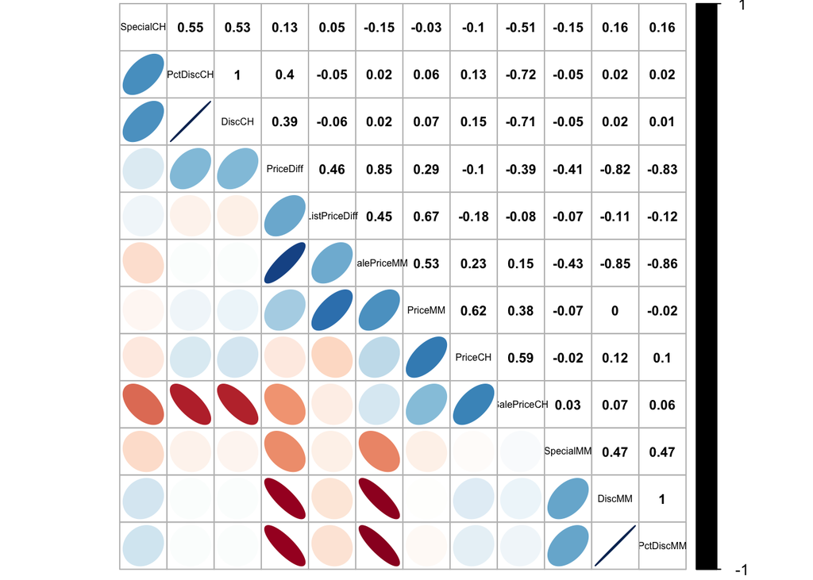

```r
PriceVariables <- purchases %>%
  select(-c(Store, WeekofPurchase, LoyalCH))

corr.priceVars <- cor(select_if(PriceVariables, is.numeric),use = "pairwise", method = "pearson")
corrplot.mixed(corr.priceVars, lower="ellipse", upper="number", number.cex = .7, upper.col ='black', tl.cex=.5, tl.col = 'black', order="AOE")
```

```r
         #       , method = "circle",tl.pos = "d",  tl.cex = 0.5, tl.col = 'black',
         # order = "hclust", diag = TRUE,title = "Correlation Plot"
         # , mar=c(1,1,1,1))
```

### Specials Variable

There are two variables detailing whether there was a special for either product. I choose to combine these variables to reduce dimensionality while increasing information by providing two additional categories - niether having a discount and both having a discount.

I first check if the data only has 2 levels, which they both do. I then combine these variables into a new Special variable.

```r
# confirm both variables only have 2 levels
PriceVariables <- purchases %>%
  mutate(
    SpecialCH = factor(SpecialCH),
    SpecialMM = factor(SpecialMM),
  )
```

### First round VIF

In a new data frame, I remove all non-price variables to check for multicollinearity. I first start by training a binomial GLM model on whether someone purchased Minute Maid orange juice or not. Immediately we see that there are perfectly correlated variables when the Variable Inflation Factor fails to run - something we saw in the correlation plot above. We check the variable coefficients to find a few of them are NAs, meaning they’re colinear. I remove these variables entirely. Looking at the variables, eg SalePrice, we can see we’re not losing information. For example, SalePrice can be calculated easily by price and percent discount.

```r
#remove non-price variables
PriceVariables <- PriceVariables %>%
  mutate(
    SpecialCH = factor(ifelse(SpecialCH == '1', "True", "False")),
    SpecialMM = factor(ifelse(SpecialMM == '1', "True", "False")),
    Purchase = ifelse(Purchase=="MM",1,0)
  ) %>%
  select(-c(Store, WeekofPurchase, LoyalCH))


set.seed(123)
model.vif <- glm(Purchase~., PriceVariables, family='binomial')

## check variable inflation factor and NAs in coefficients
### Commenting out the VIF line since it's throws on error on knitting due to perfect colinearity ###
# car::vif(model.vif)
summary(model.vif)
```

```
##
## Call:
## glm(formula = Purchase ~ ., family = "binomial", data = PriceVariables)
##
## Deviance Residuals:
##     Min       1Q   Median       3Q      Max
## -1.7585  -0.9387  -0.7608   1.1542   2.2024
##
## Coefficients: (4 not defined because of singularities)
##               Estimate Std. Error z value Pr(>|z|)
## (Intercept)     2.8357     1.4626   1.939   0.0525 .
## PriceCH         2.2882     0.9267   2.469   0.0135 *
## PriceMM        -3.6385     0.6532  -5.570 2.55e-08 ***
## DiscCH         -6.9004    15.7478  -0.438   0.6613
## DiscMM         15.7947     6.9717   2.266   0.0235 *
## SpecialCHTrue  -0.3647     0.2619  -1.393   0.1637
## SpecialMMTrue   0.4987     0.2097   2.378   0.0174 *
## SalePriceMM         NA         NA      NA       NA
## SalePriceCH         NA         NA      NA       NA
## PriceDiff           NA         NA      NA       NA
## PctDiscMM     -30.5652    14.6109  -2.092   0.0364 *
## PctDiscCH       6.2505    29.9181   0.209   0.8345
## ListPriceDiff       NA         NA      NA       NA
## ---
## Signif. codes:  0 '***' 0.001 '**' 0.01 '*' 0.05 '.' 0.1 ' ' 1
##
## (Dispersion parameter for binomial family taken to be 1)
##
##     Null deviance: 1430.9  on 1069  degrees of freedom
## Residual deviance: 1314.2  on 1061  degrees of freedom
## AIC: 1332.2
##
## Number of Fisher Scoring iterations: 4
```

```r
# remove colinear variables
PriceVariables <- PriceVariables %>%
  mutate(
    Special = ifelse(SpecialCH == "False" & SpecialMM == "False", "Absent", "Both"),
    Special = ifelse(Special == "None" & SpecialCH == "True", "CH", Special),
    Special = ifelse(Special == "None" & SpecialMM == "True", "MM", Special)
  ) %>%
  select(-c(SpecialCH, SpecialMM, SalePriceMM, SalePriceCH, PriceDiff, ListPriceDiff))
```

### Second round VIF

Next, we re-train the binomial GLM model to check variable inflation factor again. We find four variables (DiscCH, DiscMM, PctDiscMM, PctDiscCH) all return around 480. I chose to keep percent discount since I feel it provides more relative information about the extent of discount which might be lost if we keep the dollar discount variables.

I retrain the GLM one last time to check we’ve reduced all multicollinearity.

```r
## retrain
set.seed(123)
model.vif <- glm(Purchase~., PriceVariables, family='binomial')

## Multicollinearity
car::vif(model.vif)
```

```
##    PriceCH    PriceMM     DiscCH     DiscMM  PctDiscMM  PctDiscCH    Special
##   2.169243   1.844308 487.477749 478.110558 478.847556 485.981099   1.608350
```

```r
summary(model.vif)
```

```
##
## Call:
## glm(formula = Purchase ~ ., family = "binomial", data = PriceVariables)
##
## Deviance Residuals:
##     Min       1Q   Median       3Q      Max
## -1.6838  -0.9569  -0.7629   1.1703   2.1480
##
## Coefficients:
##             Estimate Std. Error z value Pr(>|z|)
## (Intercept)   2.8668     1.4589   1.965  0.04941 *
## PriceCH       2.3639     0.9252   2.555  0.01062 *
## PriceMM      -3.7213     0.6534  -5.695 1.23e-08 ***
## DiscCH        3.4647    16.0394   0.216  0.82898
## DiscMM       17.8121     6.8134   2.614  0.00894 **
## PctDiscMM   -34.7499    14.2830  -2.433  0.01498 *
## PctDiscCH   -15.2598    30.2795  -0.504  0.61429
## SpecialBoth   0.2552     0.1860   1.372  0.17009
## ---
## Signif. codes:  0 '***' 0.001 '**' 0.01 '*' 0.05 '.' 0.1 ' ' 1
##
## (Dispersion parameter for binomial family taken to be 1)
##
##     Null deviance: 1430.9  on 1069  degrees of freedom
## Residual deviance: 1322.5  on 1062  degrees of freedom
## AIC: 1338.5
##
## Number of Fisher Scoring iterations: 4
```

```r
PriceVariables <- PriceVariables %>%
  select(-c(DiscCH, DiscMM))

## retrain
set.seed(123)
model.vif <- glm(Purchase~., PriceVariables, family='binomial')

## If residuals are distributed normally;their mean should be zero or low
mean(model.vif$residuals)
```

```
## [1] -0.001306809
```

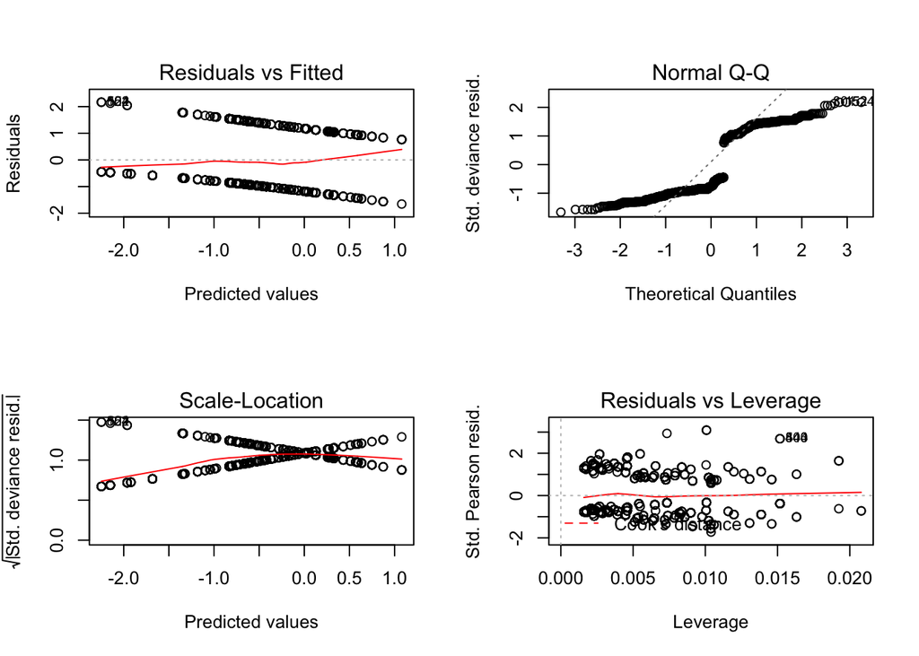

```r
## homoscedasticity of residuals
par(mfrow=c(2, 2))
plot(model.vif)
```

```r
## Multicollinearity
car::vif(model.vif)
```

```
##   PriceCH   PriceMM PctDiscMM PctDiscCH   Special
##  1.824279  1.688000  1.473632  1.156012  1.573351
```

```r
summary(model.vif)
```

```
##
## Call:
## glm(formula = Purchase ~ ., family = "binomial", data = PriceVariables)
##
## Deviance Residuals:
##     Min       1Q   Median       3Q      Max
## -1.6561  -0.9323  -0.7585   1.1253   2.1669
##
## Coefficients:
##             Estimate Std. Error z value Pr(>|z|)
## (Intercept)   1.2916     1.2536   1.030 0.302896
## PriceCH       2.7360     0.8446   3.239 0.001198 **
## PriceMM      -3.3053     0.6183  -5.346 9.00e-08 ***
## PctDiscMM     2.5782     0.7831   3.292 0.000994 ***
## PctDiscCH    -8.6861     1.4914  -5.824 5.74e-09 ***
## SpecialBoth   0.2391     0.1833   1.304 0.192064
## ---
## Signif. codes:  0 '***' 0.001 '**' 0.01 '*' 0.05 '.' 0.1 ' ' 1
##
## (Dispersion parameter for binomial family taken to be 1)
##
##     Null deviance: 1430.9  on 1069  degrees of freedom
## Residual deviance: 1329.4  on 1064  degrees of freedom
## AIC: 1341.4
##
## Number of Fisher Scoring iterations: 4
```

### Checking and pushing changes

I revisit the price variables one last time using a pairs panels before applying the changes I found to the main dataset.

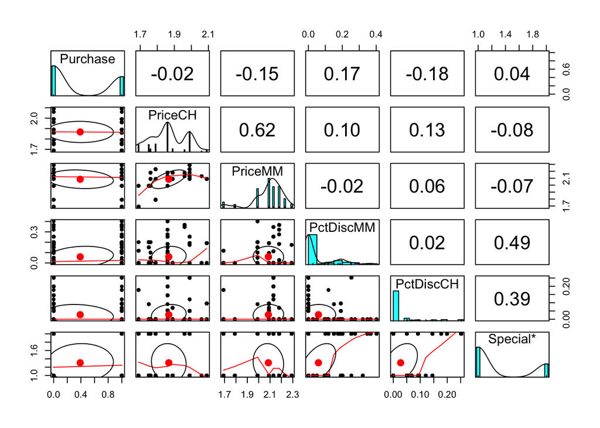

```r
pairs.panels(PriceVariables)
```

```r
purchases <- purchases %>%
  mutate(
    Purchase = ifelse(Purchase=="MM",1,0),
    Special = ifelse(SpecialCH == 1 & SpecialMM == 1, "Both", "Absent"),
    Special = ifelse(Special == "Absent" & SpecialCH == 1, "CH", Special),
    Special = ifelse(Special == "Absent" & SpecialMM == 1, "MM", Special),
    Special = factor(Special)
  ) %>%
  select(-c(SpecialCH, SpecialMM, SalePriceMM, SalePriceCH, PriceDiff, ListPriceDiff, DiscCH, DiscMM))
```

## Week Variable

Included in the dataset is a numeric variable indicating the week. Week 227 in this case is the week of Jan 1. There are two opportunities here for future analysis. First, indicating which year the data is from can aid in knowing which weeks have holidays and more accurate month labels. Second, obtaining extended data for the year(s) before or after this one can help uncover if seasonality exists in the data.

I start out by converting the numeric week to a timestamp, randomly picking 2010 as the year. I group all purchases by week and plot total orange juice units sold and what percent of sales are Minute Maid. There seems to be some seasonality here, though it’s hard to map events like Easter to a specific week.

```r
purchasesDates <- purchases %>%
  mutate(
    purchaseDate = as.Date(((WeekofPurchase-18)*7), origin="2010-01-01"),
    purchaseMonth = month(ymd(purchaseDate), label=TRUE),
    purchaseWeek = week(ymd(purchaseDate))
  )

byWeek <- purchasesDates %>%
  group_by(purchaseWeek) %>%
  summarise(
    sales = sum(Purchase),
    total = n(),
    percentMM = sum(Purchase)/n()
  )
```

[figure not shown]

```r
ggplot(byWeek, aes(purchaseWeek,total)) +
    geom_col() +
  labs(title="Total Sales per Month", x="Total Units Sold", y="Month", subtitle = "There appears to be slight seasonality in sales - with higher sales in winter months.")
```

[figure not shown]

```r
ggplot(byWeek, aes(purchaseWeek, percentMM)) +
    geom_col() +
  labs(title="Minute Maid Sales Share per Month", x="Percent of Sales", y="Month", subtitle = "Minute Maid accounted for a higher percent of sales during Winter months.")
```

Looking at price and special for Minute Maid by month, it’s not immediately clear whether the seasonal variation is caused by the higher product price during the summer months or true seasonality. To explore this further, I suggest using data from multiple years to check for seasonality using something like auto-arima.

```r
byMonth <- purchasesDates %>%
  group_by(purchaseMonth) %>%
  summarise(
    sales = sum(Purchase),
    total = n(),
    percentMM = sum(Purchase)/n()
  )
```

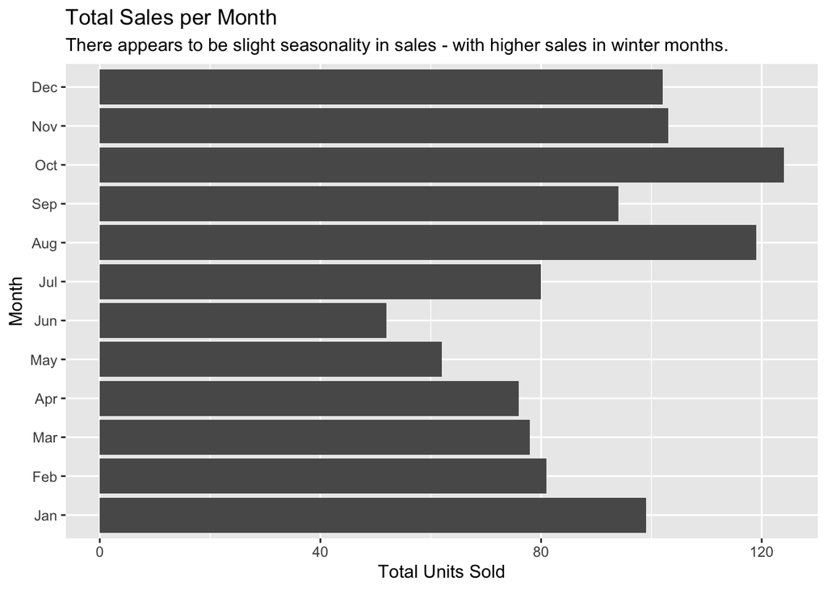

```r
ggplot(byMonth, aes(total, purchaseMonth)) +
    geom_col() +
  labs(title="Total Sales per Month", x="Total Units Sold", y="Month", subtitle = "There appears to be slight seasonality in sales - with higher sales in winter months.")
```

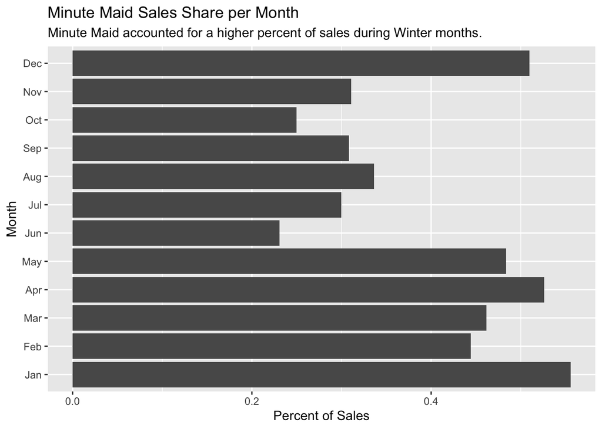

```r
ggplot(byMonth, aes(percentMM, purchaseMonth)) +
    geom_col() +
  labs(title="Minute Maid Sales Share per Month", x="Percent of Sales", y="Month", subtitle = "Minute Maid accounted for a higher percent of sales during Winter months.")
```

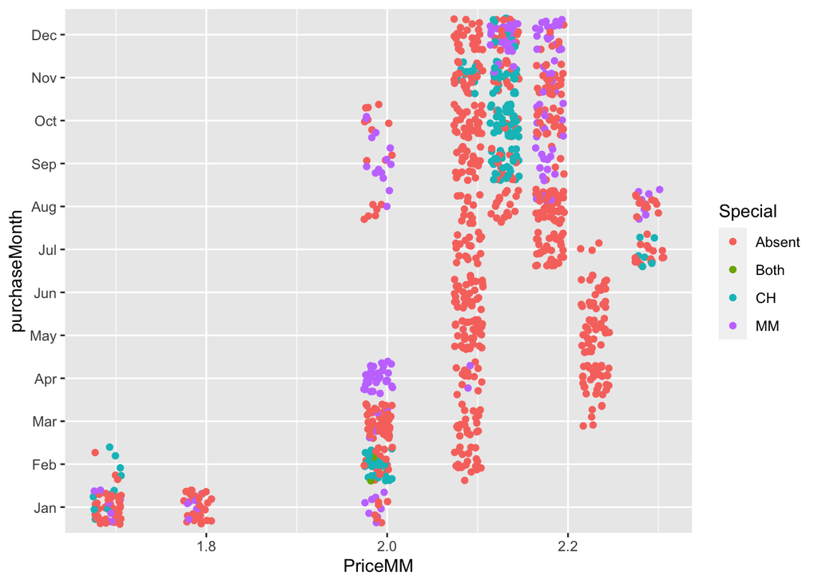

```r
ggplot(purchasesDates, aes(PriceMM, purchaseMonth, color=Special)) +
  geom_jitter()
```

```r
#add to main dataframe
purchases <- purchases %>%
  mutate(
    purchaseMonth = month(ymd(as.Date(((WeekofPurchase-18)*7), origin="2010-01-01")), label=TRUE)
  ) %>%
  select(-WeekofPurchase)
```

## Descriptive Model Variables

Now that I finished cleaning the data, we end up with 3 categorical variables and 6 numeric variables, described below.

```r
skim(purchases)
```

Data summary

| Name | purchases |
| --- | --- |
| Number of rows | 1070 |
| Number of columns | 9 |
| _______________________ |  |
| Column type frequency: |  |
| factor | 3 |
| numeric | 6 |
| ________________________ |  |
| Group variables | None |

**Variable type: factor**

| skim_variable | n_missing | complete_rate | ordered | n_unique | top_counts |
| --- | --- | --- | --- | --- | --- |
| Store | 0 | 1 | FALSE | 5 | 7: 356, 2: 222, 3: 196, 1: 157 |
| Special | 0 | 1 | FALSE | 4 | Abs: 743, MM: 169, CH: 154, Bot: 4 |
| purchaseMonth | 0 | 1 | TRUE | 12 | Oct: 124, Aug: 119, Nov: 103, Dec: 102 |

**Variable type: numeric**

| skim_variable | n_missing | complete_rate | mean | sd | p0 | p25 | p50 | p75 | p100 | hist |
| --- | --- | --- | --- | --- | --- | --- | --- | --- | --- | --- |
| Purchase | 0 | 1 | 0.39 | 0.49 | 0.00 | 0.00 | 0.00 | 1.00 | 1.00 | ▇▁▁▁▅ |
| PriceCH | 0 | 1 | 1.87 | 0.10 | 1.69 | 1.79 | 1.86 | 1.99 | 2.09 | ▅▂▇▆▁ |
| PriceMM | 0 | 1 | 2.09 | 0.13 | 1.69 | 1.99 | 2.09 | 2.18 | 2.29 | ▂▁▃▇▆ |
| LoyalCH | 0 | 1 | 0.57 | 0.31 | 0.00 | 0.33 | 0.60 | 0.85 | 1.00 | ▅▃▆▆▇ |
| PctDiscMM | 0 | 1 | 0.06 | 0.10 | 0.00 | 0.00 | 0.00 | 0.11 | 0.40 | ▇▁▂▁▁ |
| PctDiscCH | 0 | 1 | 0.03 | 0.06 | 0.00 | 0.00 | 0.00 | 0.00 | 0.25 | ▇▁▁▁▁ |

### Descriptive Model

There’s three variables which are significant at p<.001: * Loyalty to Citrus Hill * Percent Discount on Minute Maid * Percent Discount on Citrus Hill

For someone purchasing Minute Maid, the odds of them also being loyal to Citrus Hill is .00172 to 1. In other words, brand loyalty to Citrus Hill is a very strong determining factor in whether someone buys Minute Maid. As past purchase history of Citrus Hill increases, the probability of buying Minute Maid in teh future decreases.

Percent discount on both brands should also be a significant factor in any future actions. As the percent discount for Citrus Hill increases, the probability of buying minute maid decreases with an odds ratio of .00023 to 1. Alternatively, the odds are flipped when the percent discount is applied to Minute Maid: 110.9 to 1.

It’s important to note that a percent decrease in sale price of Citrus Hill has a stronger correlation than on the same percent descrease in the sale price of Minute Maid.

```r
set.seed(123)
model.glm <- glm(Purchase~., purchases, family=binomial(link='logit'))
summary(model.glm)
```

```
##
## Call:
## glm(formula = Purchase ~ ., family = binomial(link = "logit"),
##     data = purchases)
##
## Deviance Residuals:
##     Min       1Q   Median       3Q      Max
## -2.7392  -0.5324  -0.2082   0.5185   2.8600
##
## Coefficients:
##                   Estimate Std. Error z value Pr(>|z|)
## (Intercept)        9.35766    5.46730   1.712  0.08698 .
## PriceCH           -0.48906    2.62105  -0.187  0.85198
## PriceMM           -2.80515    1.39697  -2.008  0.04464 *
## LoyalCH           -6.36545    0.41887 -15.197  < 2e-16 ***
## PctDiscMM          4.70896    1.27455   3.695  0.00022 ***
## PctDiscCH         -8.37855    2.19017  -3.826  0.00013 ***
## Store2             0.22568    0.29196   0.773  0.43952
## Store3             0.48937    0.47730   1.025  0.30523
## Store4             0.27312    0.51210   0.533  0.59381
## Store7            -0.52572    0.31309  -1.679  0.09313 .
## SpecialBoth      -14.54781  618.92929  -0.024  0.98125
## SpecialCH          0.56144    0.37693   1.490  0.13635
## SpecialMM          0.21292    0.31310   0.680  0.49648
## purchaseMonth.L    0.89517    0.80633   1.110  0.26692
## purchaseMonth.Q    0.02354    0.47779   0.049  0.96070
## purchaseMonth.C    0.62822    0.42604   1.475  0.14033
## purchaseMonth^4    0.69786    0.39051   1.787  0.07393 .
## purchaseMonth^5    0.09178    0.32540   0.282  0.77789
## purchaseMonth^6    0.92915    0.36858   2.521  0.01170 *
## purchaseMonth^7   -0.05600    0.33957  -0.165  0.86901
## purchaseMonth^8   -0.52784    0.33749  -1.564  0.11781
## purchaseMonth^9    0.01234    0.34868   0.035  0.97177
## purchaseMonth^10   0.22691    0.34575   0.656  0.51164
## purchaseMonth^11  -0.71529    0.36619  -1.953  0.05078 .
## ---
## Signif. codes:  0 '***' 0.001 '**' 0.01 '*' 0.05 '.' 0.1 ' ' 1
##
## (Dispersion parameter for binomial family taken to be 1)
##
##     Null deviance: 1430.85  on 1069  degrees of freedom
## Residual deviance:  802.61  on 1046  degrees of freedom
## AIC: 850.61
##
## Number of Fisher Scoring iterations: 14
```

```r
exp(cbind(Odds_Ratio = coef(model.glm)))
```

```
##                    Odds_Ratio
## (Intercept)      1.158724e+04
## PriceCH          6.132004e-01
## PriceMM          6.049744e-02
## LoyalCH          1.719972e-03
## PctDiscMM        1.109371e+02
## PctDiscCH        2.297438e-04
## Store2           1.253176e+00
## Store3           1.631284e+00
## Store4           1.314056e+00
## Store7           5.911298e-01
## SpecialBoth      4.808034e-07
## SpecialCH        1.753202e+00
## SpecialMM        1.237287e+00
## purchaseMonth.L  2.447749e+00
## purchaseMonth.Q  1.023823e+00
## purchaseMonth.C  1.874280e+00
## purchaseMonth^4  2.009454e+00
## purchaseMonth^5  1.096128e+00
## purchaseMonth^6  2.532365e+00
## purchaseMonth^7  9.455402e-01
## purchaseMonth^8  5.898749e-01
## purchaseMonth^9  1.012415e+00
## purchaseMonth^10 1.254720e+00
## purchaseMonth^11 4.890493e-01
```

# Conclusion and Results

## Implications for the Brand team

**What predictor variables influence the purchaseof MM?**

Being loyal to Citrus Hill, a higher price of Minute Maid, and a higher percent discount for Citrus Hill will all lower the probability of a customer purchasing Minute Maid.

**Are all the variables in the dataset effective or are some more effective than others?**

There were a lot of variables which were very similar, indeed some were perfectly correlated.